# REDME: Short explanation about the results.

## Introduction

The final script to fit the data is in “Apply to data Frame.R”

## Reading and cleaning the data

File “01-data_load.R” contains the code to load and clean the data, As the durations are influenced by the connection speed (Band) we correct duration values based on the simple linear model Duratiion~Band+Age +Gender. Then we extract the impact on the band from the duration. the modified data are also saved in the “Final_results.RData” file.

```r
DT <- as.data.table(read.csv('http://doitprofiler.com/wp-content/uploads/2016/06/RKrakowFinalData.csv', stringsAsFactors = F))
source("01-data_load.R")
summary(model1)
```

```
##
## Call:
## lm(formula = mean_duration_person ~ Band + Gender + AgeYears,
##     data = DT)
##
## Residuals:
##     Min      1Q  Median      3Q     Max
## -8.2122 -2.7682 -0.9535  1.4053 29.5486
##
## Coefficients:
##             Estimate Std. Error t value Pr(>|t|)
## (Intercept)  8.23731    0.46284  17.797  < 2e-16 ***
## Band        -0.52164    0.10585  -4.928 9.01e-07 ***
## GenderM     -0.31592    0.20740  -1.523    0.128
## AgeYears     0.06034    0.01409   4.283 1.94e-05 ***
## ---
## Signif. codes:  0 '***' 0.001 '**' 0.01 '*' 0.05 '.' 0.1 ' ' 1
##
## Residual standard error: 4.407 on 1917 degrees of freedom
## Multiple R-squared:  0.02656,    Adjusted R-squared:  0.02504
## F-statistic: 17.43 on 3 and 1917 DF,  p-value: 3.619e-11
```

## Predicting the gender from the set of data

To answer the question whether there are real differences between Male and Females we try to classify individuals into gender classes based on the answers and their duration. To do this we apply a random forest algorithm for classification. The plot presents the importance of the variables in predicting gender

```r
source("03-predict_gender_random_forest.R")
```

```
## [1] 0.612
```

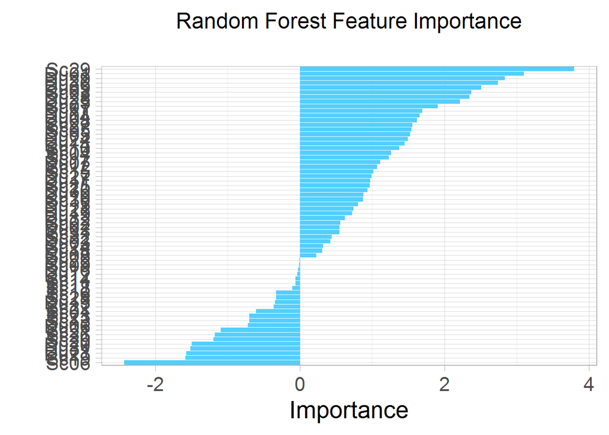

We achieve rate of prediction :61% which is more then randomly guessing. This shows that there is some difference between genders in the test results and strategies.

## Predicting the score from the set of data

To find out which variables actually are good predictors of the final score we apply a regression method together with random forest. The below plot presents the importance of the single answers and durations as well as gender in predicting scores.

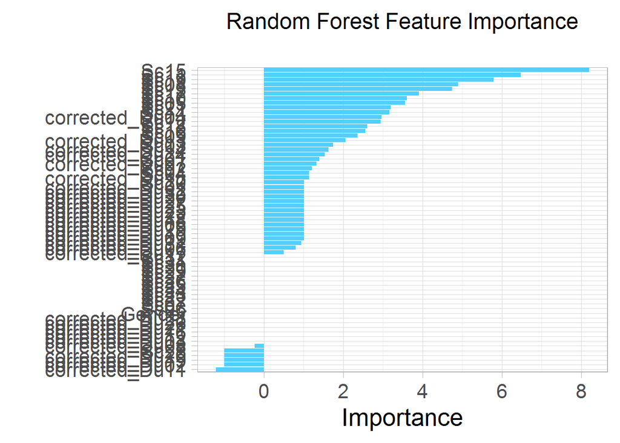

```r
p#plot of importance without scores on single questions
```

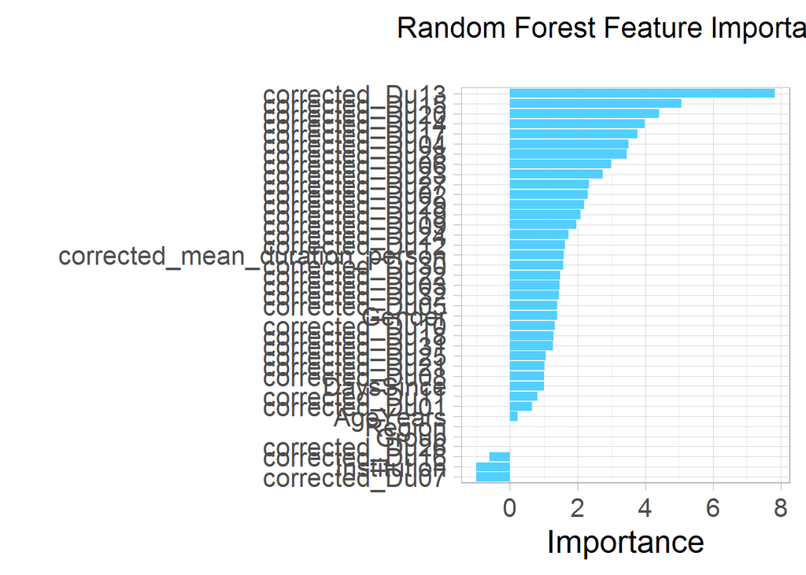

```r
p1# plot of importance without scores on single questions
```

As one can observe on the picture the gender is not helpful in predicting final score. Several question’s durations are much more important then the Gender. It led us to the conclusion that the gender is not pivotal to the test results. Longer durations on a specific questions may indicate that a person is applying a different startegy. Thus the difference acress genders appear to be a difference of applie strategies.

## Calculating scores

The objective function we minimized is the absolute sum of the mean differences between genders across the 80 subgroups.

We applied several approaches to minimize the objective functions and present two in the final code. This code is in the file “07-correct_score_fun”. The optimization procedure is implemented there.

Function “score” calculate the metric given 32 weights, each to a different question. It additionally penalizes the devation from equally weighted solution. This is done to decrease the overfitting of the data.

```r
score <- function(row, w, v, lambda, penalty = function(x) abs(x)) {

  length_answers <- length(na.omit(row[Sc_cols]))

  output <- w * row[Sc_cols]  + lambda * penalty(w - 1/32)

  output <- output/length_answers

  return(sum(output, na.rm = TRUE))
}#plot of importance without scores on single questions
```

```r
score3 <- function(row, w, v, lambda, penalty = function(x) sqrt(abs(x))){

  length_answers <- length(na.omit(row[Sc_cols]))

  output <- w * row[Sc_cols] - v * row[Sd_corrected_cols] + lambda * (penalty(w)+penalty(v))


  output <- output/length_answers

  return(sum(output, na.rm = TRUE))
}
```

To get the result we minimized the weighted gender gap in the subgroups:

```r
load( file = "Final_results.RData")
# after calculating the score we aggregate it into avarege female and male score in the group
head(DT_groups_casted)
```

```
##                      SubGroup1         F         M group_count  group_part
## 1:                             0.2256583 0.2585966         114 0.060897436
## 2:           Ancilliary Health 0.2950767        NA           2 0.001068376
## 3:          Auto Electrical N1 0.2564474 0.1636212           5 0.002670940
## 4: Auto Motive (Mechanical) N1 0.1732432 0.2309399          20 0.010683761
## 5:         Automotive (ERD) L2 0.2212811 0.2038539          28 0.014957265
## 6:            Boiler Making N1 0.2141140 0.2170061          25 0.013354701
##    gender_gap
## 1:  3.7549589
## 2:         NA
## 3:  0.4641311
## 4:  1.1539339
## 5:  0.4879606
## 6:  0.0723024
```

```r
#calculate gender gaps
DT_groups_casted[, gender_gap := abs(`F` - `M`) * group_count]

#and calculate the objective function
print(DT_groups_casted[, sum(gender_gap, na.rm = TRUE)])
```

```
## [1] 69.76396
```

```r
print(" then we minimize tis objective")
```

```
## [1] " then we minimize tis objective"
```

The final models were chosen based on the cross validation on the data. As this process was lengthy we do not present it here but only provide the function to crossvalidate on the data. “08-crossvalidate.R”

As the optimization process is lengthy, the final values are saved to a file and the final function calls use the optimized parameters. The file to call on the competition data is “apply to data frame.R”

To get the result we minimized the weighted gender gap in the subgroups:

```r
load( file = "Final_results.RData")
print("final score weightings for the zero method")
```

```
## [1] "final score weightings for the zero method"
```

```r
a[1:32]
```

```
##  [1] 0.000000000 0.000000000 0.000000000 0.045052203 0.000000000
##  [6] 0.044975359 0.000000000 0.000000000 0.044994953 0.007218454
## [11] 0.000000000 0.042766132 0.029324364 0.010814932 0.000000000
## [16] 0.000000000 0.000000000 0.000000000 0.000000000 0.042543909
## [21] 0.000000000 0.000000000 0.030679430 0.000000000 0.000000000
## [26] 0.044984231 0.045025988 0.023430623 0.000000000 0.043057818
## [31] 0.044694382 0.000000000
```

```r
print("final score weightings for the first method")
```

```
## [1] "final score weightings for the first method"
```

```r
a1[1:32]
```

```
##  [1] 0.00000000 0.00000000 0.00000000 0.00000000 0.00000000 0.00000000
##  [7] 0.03852431 0.00000000 0.00000000 0.00000000 0.00000000 0.00000000
## [13] 0.00000000 0.00000000 0.00000000 0.03639951 0.00000000 0.00000000
## [19] 0.00000000 0.03853074 0.00000000 0.00000000 0.03853074 0.03853074
## [25] 0.03853074 0.03853074 0.03803460 0.03853074 0.03853074 0.03853074
## [31] 0.03853074 0.03853074
```

```r
print("final duration penalties  for the first method")
```

```
## [1] "final duration penalties  for the first method"
```

```r
a1[33:64]
```

```
##  [1] 0.05683092 0.00000000 0.00000000 0.00000000 0.00000000 0.00000000
##  [7] 0.05683100 0.00000000 0.00000000 0.00000000 0.00000000 0.05683100
## [13] 0.00000000 0.00000000 0.00000000 0.00000000 0.00000000 0.00000000
## [19] 0.05683096 0.05683100 0.04776987 0.00000000 0.00000000 0.00000000
## [25] 0.00000000 0.00000000 0.00000000 0.00000000 0.00000000 0.05678452
## [31] 0.05640705 0.05661787
```